# Homework 11

Joe Dickerson

2025-04-18

```r
library(faraway)
library(tidyverse)
library(lme4)
```

1. The ratdrink data consist of five weekly measurements of body weight for 27 rats. The first 10 rats are on a control treatment while 7 rats have thyroxine added to their drinking water. Ten rats have thiouracil added to their water.
1. Plot the data showing how weight increases with age on a single panel, taking care to distinguish the three treatment groups. Now create a three-panel plot, one for each group. Discuss what can be seen.

We see similar weight increase between the control group and the thyroxine group, while thiouracil has a smaller increase of weight over time. This is also illustrated when looking at the means over time.

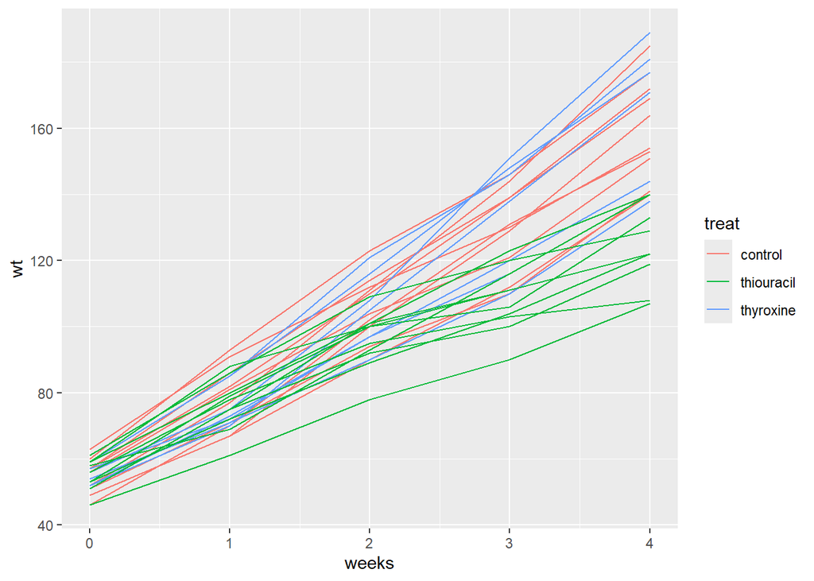

```r
data(ratdrink)

ratdrink %>%
  ggplot(aes(x = weeks, y = wt, color = treat, group = subject)) +
  geom_line()
```

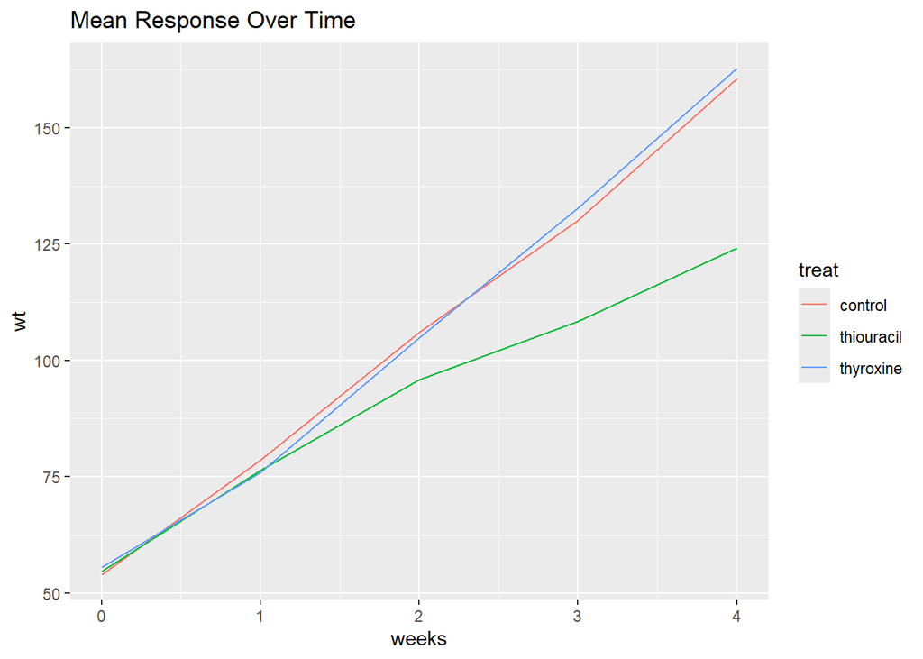

```r
ratdrink %>%
  ggplot(aes(x = weeks, y = wt, group = treat)) +
  geom_line(aes(color = treat), stat = "summary", fun = mean) +
  labs(title = "Mean Response Over Time")
```

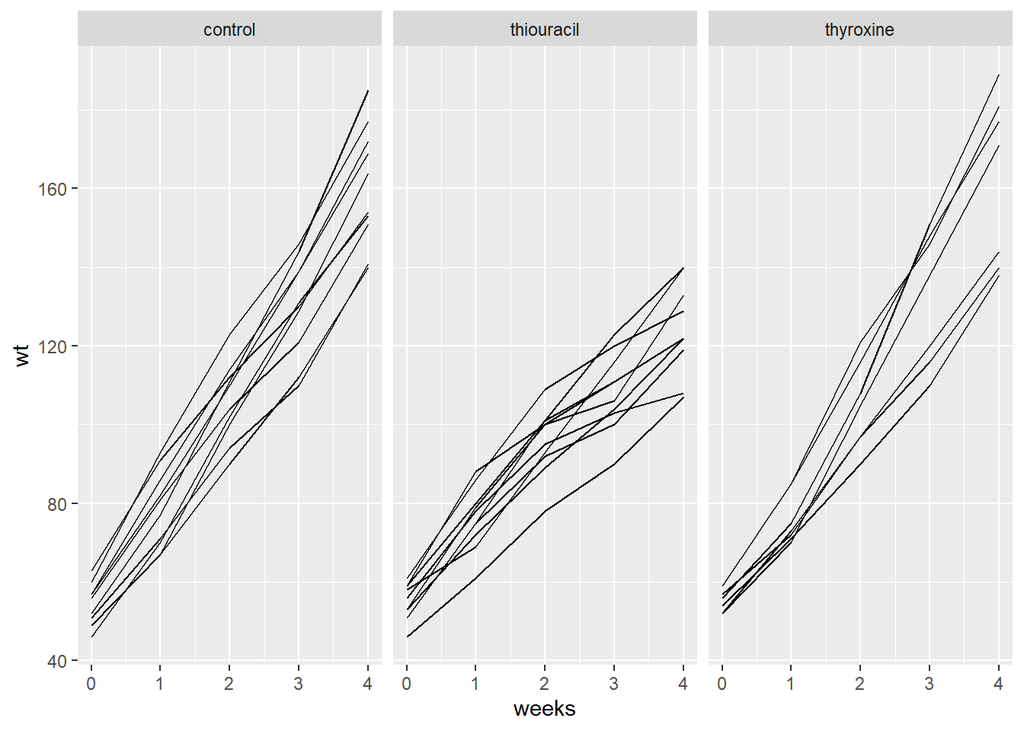

```r
ratdrink %>%
  ggplot(aes(x = weeks, y = wt, group = subject)) +
  geom_line() +
  facet_wrap(~ treat)
```

2. Fit a linear longitudinal model that allows for a random slope and intercept for each rat. Each group should have a different mean line. Give interpretation for the following estimates:
3. The fixed effect intercept term.
2. The interaction between thiouracil and week.
3. The intercept random effect SD.
4. We expect the weight of a rat in the control group at week 0 to be 52.88 units.
5. There appears to be significance for the treatment effect of thiouracil. The effect is large relative to the size of the standard error. The rats in this group gain less weight over time than the rats in the other two groups. The t-value is rather large which confirms this, and our estimate of -9.37 indicates we expect a rate to gain -9.37 units of weight less than a rat in the control group over time.
6. We expect that any rat at week 0 will have a starting weight within 5.7 units above or below the mean.

```r
ratdrink %>%
  mutate(subject = factor(subject))
```

[output not shown]

[output cut: 121 more lines]

```r
mmod <- lmer(wt ~ treat*weeks + (1+weeks|subject), data = ratdrink)

summary(mmod)
```

```
## Linear mixed model fit by REML ['lmerMod']
## Formula: wt ~ treat * weeks + (1 + weeks | subject)
##    Data: ratdrink
##
## REML criterion at convergence: 878.7
##
## Scaled residuals:
##      Min       1Q   Median       3Q      Max
## -1.83136 -0.54991  0.04003  0.58230  2.03660
##
## Random effects:
##  Groups   Name        Variance Std.Dev. Corr
##  subject  (Intercept) 32.49    5.700
##           weeks       14.14    3.760    -0.13
##  Residual             18.90    4.348
## Number of obs: 135, groups:  subject, 27
##
## Fixed effects:
##                       Estimate Std. Error t value
## (Intercept)            52.8800     2.0937  25.256
## treatthiouracil         4.7800     2.9610   1.614
## treatthyroxine         -0.7943     3.2628  -0.243
## weeks                  26.4800     1.2661  20.915
## treatthiouracil:weeks  -9.3700     1.7905  -5.233
## treatthyroxine:weeks    0.6629     1.9730   0.336
##
## Correlation of Fixed Effects:
##             (Intr) trtthr trtthy weeks  trtthr:
## treatthircl -0.707
## treatthyrxn -0.642  0.454
## weeks       -0.250  0.177  0.160
## trtthrcl:wk  0.177 -0.250 -0.113 -0.707
## trtthyrxn:w  0.160 -0.113 -0.250 -0.642  0.454
```

3. Check whether there is a significant treatment effect.

There appears to be a significant treatment effect as we have a significant p-value when performing an F test with the Kenward-Roger approach. This seems to follow what we found in the model summary.

```r
library(pbkrtest)


mmod1 <- lmer(wt ~ treat*weeks + (1+weeks|subject), data = ratdrink, REML = FALSE)

mmod2 <- lmer(wt ~ 1 + (1+weeks|subject), data = ratdrink, REML = FALSE)

KRmodcomp(mmod1, mmod2)
```

```
## large : wt ~ treat + weeks + (1 + weeks | subject) + treat:weeks
## small : wt ~ 1 + (1 + weeks | subject)
##          stat     ndf     ddf F.scaling   p.value
## Ftest 178.875   5.000  28.738   0.94941 < 2.2e-16 ***
## ---
## Signif. codes:  0 '***' 0.001 '**' 0.01 '*' 0.05 '.' 0.1 ' ' 1
```

4. Construct diagnostic plots showing the residuals against the fitted values and a QQ plot of the residuals. Interpret.

We have acceptable diagnostic plots, both residual vs. fitted values and the Q-Q plot.

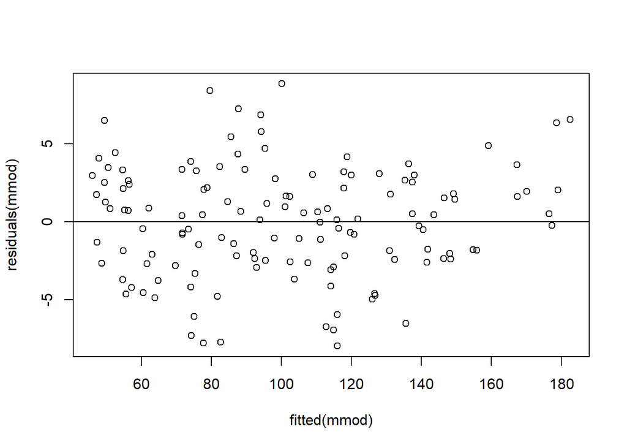

```r
plot(residuals(mmod) ~ fitted(mmod))
abline(h=0)
```

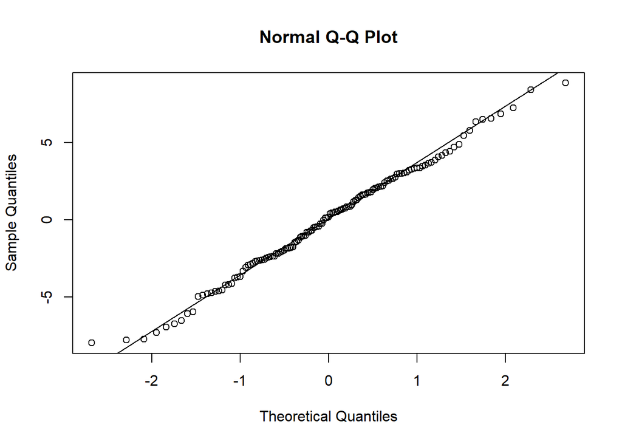

```r
qqnorm(residuals(mmod))
qqline(residuals(mmod))
```

5. Construct confidence intervals for the parameters of the model. Which random effect terms may not be significant? Is the thyroxine group significantly different from the control group?

The thyroxine group includes 0, so there might not be a significant effect of thyroxine on weight. It does not appear to be significantly different from the control group. We also see that thiouracil seems to have a strong negative interaction.

```r
set.seed(123)

confint(mmod, method="boot")
```

```
## Computing bootstrap confidence intervals ...
```

```
##
## 3 warning(s): Model failed to converge with max|grad| = 0.0020237 (tol = 0.002, component 1) (and others)
```

```
##                             2.5 %     97.5 %
## .sig01                  3.3628251  7.8154943
## .sig02                 -0.5776008  0.4542672
## .sig03                  2.4935546  4.7651807
## .sigma                  3.6858820  5.0551998
## (Intercept)            48.6253473 57.0112552
## treatthiouracil        -1.6601484 11.3869198
## treatthyroxine         -6.9607186  6.0610076
## weeks                  24.0976647 29.1120273
## treatthiouracil:weeks -13.0786270 -5.7257854
## treatthyroxine:weeks   -3.3504589  4.5390441
```